# Project 3: Perfect Vine Compilation

## Group 7

### Hayley Carney, Rohan Enagala, Stephen Jennings, Basil Mullings, Utkarsh Karki, Sandeep Sonawane

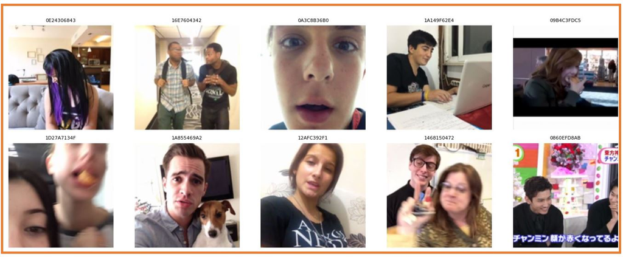

# Overview

In this project, we apply principles of digital archaeology to a historical media platform: Vine. Rather than close reading a single text, we treat thousands of short, looping Vine videos as a digitally excavated cultural layer an archive of early 2010s visual expression, humor, performance, and internet subculture. By transforming each Vine into a structured collection of metadata, embeddings, thumbnails, transcripts, and visual features, we turn an ephemeral social media platform into a computationally tractable dataset.

To explore this landscape, we designed a full analytical pipeline within a Jupyter Notebook environment. We loaded a JSONL dataset of Vine embeddings, cleaned and standardized metadata, and used clustering algorithms (K-Means with various parameters) to group videos by latent similarity. Dimensionality reduction tools such as t-SNE allowed us to visualize the semantic space of Vine content in two dimensions, revealing natural “neighborhoods” of musical performances, comedy skits, sports tricks, pet videos, and more. After inspecting clusters visually using thumbnail grids, we selected a entertainment oriented subset of the data and identified a compelling subtheme focused on performers and entertainers. This cluster became the foundation for our curated narrative arc.

The final stage involved human guided refinement and creative assembly. From the target cluster, we manually reviewed thumbnails, verified family friendly content using automated NSFW detection and human confirmation, and selected fifty clips that supported a coherent emotional and thematic progression. These videos were sorted into a dramatic structure beginning with intimate close ups of performers, transitioning through expressive and candid moments, and culminating in dynamic performance sequences. We then generated a storyboard, constructed an FFmpeg ready concatenation file, and produced the final compilation video. Taken together, our project integrates computational clustering, visual analytics, and human curation to reconstruct a meaningful and narratively cohesive artifact from a fragmented digital collection.

## Imports and Installs

```python
####Import all the core/necessary packages & Libraries we'll need.

import json
import numpy as np
import pandas as pd
from sklearn.cluster import KMeans
from sklearn.decomposition import PCA
from sklearn.manifold import TSNE
import matplotlib.pyplot as plt
import time
from pathlib import Path
from PIL import Image, ImageFilter
#from IPython.display import display, Image, HTML
from IPython.display import display, HTML

from concurrent.futures import ProcessPoolExecutor, as_completed
import os, math

### pip install tqdm maybe needed.
#from tqdm.notebook import tqdm
from tqdm.auto import tqdm

# Make plots a bit nicer
plt.style.use("default")
plt.rcParams["figure.figsize"] = (10, 8)
```

```python
import warnings
warnings.filterwarnings('ignore')
```

## Configuration

```python
####General configuration items in one area.

##Basil
THUMBNAIL_BASE_DIR = Path('E:/UtKnox/Courses/Fall_2025/COSC545 - Digital Archeology/Module_7/Team Project/Data/thumbs')
INPUT_JSONL_FILE = 'E:/UtKnox\Courses/Fall_2025/COSC545 - Digital Archeology/Module_7/Team Project/Data/vine_embeddings_plus.jsonl'

##Hayley
#THUMBNAIL_BASE_DIR = Path('/Users/hayleygoldblatt/Documents/cosc545/m7_p3_perfect_vine_compilation/Data/thumbs')
#INPUT_JSONL_FILE = '/Users/hayleygoldblatt/Documents/cosc545/m7_p3_perfect_vine_compilation/Data/vine_embeddings_plus.jsonl'

##Jay
#THUMBNAIL_BASE_DIR = Path('/Users/jaykarki/Downloads/thumbs')
#INPUT_JSONL_FILE = '/Users/jaykarki/Downloads/vine_embeddings_plus.jsonl'

#N_CLUSTERS = 5000
N_CLUSTERS = 50
RANDOM_STATE = 41
RANDOM_SEED = 41

MAX_TSNE_POINTS = 3000   # subsample size for t-SNE
TSNE_PERPLEXITY = 35

np.random.seed(RANDOM_SEED)

FIG_SIZE = (12, 10)
DOT_SIZE = 10
```

## Helper Functions

```python
####Streamline all/most of our needed helper functions here.

def display_video_thumbnails(df_or_ids, max_images=25, columns=5, title="Selected Videos"):
    """
    Retrieves and displays thumbnail images for a list of videos.

    Args:
        df_or_ids (pd.DataFrame or list/pd.Series):
            Either a DataFrame containing 'video_id_short' or a list/Series
            of 'video_id_short' strings.
        max_images (int): The maximum number of images to display. Defaults to 25.
        columns (int): The number of columns in the display grid. Defaults to 5.
        title (str): The title for the plot. Defaults to "Selected Videos".
    """

    # --- 1. Determine the list of short IDs ---
    if isinstance(df_or_ids, pd.DataFrame):
        if 'video_id_short' not in df_or_ids.columns:
            print("❌ Error: DataFrame must contain the 'video_id_short' column.")
            return
        # Use the IDs from the DataFrame (e.g., if we pass df_data[:10])
        short_ids = df_or_ids['video_id_short'].tolist()

    elif isinstance(df_or_ids, (list, pd.Series)):
        # Use the list or Series directly (e.g., if we pass short_ids_list)
        short_ids = list(df_or_ids)

    else:
        print("❌ Error: Input must be a DataFrame, list, or pandas Series of IDs.")
        return

    if not short_ids:
        print("📦 Found 0 IDs to display.")
        return


    num_found = len(short_ids)
    print(f"📦 Found {num_found} IDs. Displaying first {min(num_found, max_images)}.")

    # Limit the number of IDs to display
    ids_to_display = short_ids[:max_images]
    num_to_display = len(ids_to_display)

    # Calculate rows needed for the grid display
    rows = (num_to_display + columns - 1) // columns

    # 2. Setup the plot grid
    plt.figure(figsize=(columns * 3, rows * 3))
    plt.suptitle(f"Thumbnails for: {title}", fontsize=16)
    # print(",".join(short_ids)) # Optionally removed this large print

    # 3. Iterate through IDs and display images
    for i, video_id in enumerate(ids_to_display):
        # Construct the full path
        image_path = THUMBNAIL_BASE_DIR / f"{video_id}.png"

        plt.subplot(rows, columns, i + 1)

        # Determine the ID string to display in the title
        displayed_id = video_id
        try:
            # Load and display the image
            img = Image.open(image_path)
            plt.imshow(img)

            # Use the possibly censored ID for the title
            plt.title(f"{displayed_id}", fontsize=8)
            plt.axis('off') # Hide axis ticks and labels

        except FileNotFoundError:
            plt.title("Missing", fontsize=8, color='red')
            plt.text(0.5, 0.5, "Image Not Found", ha='center', va='center', color='red')
            plt.axis('off')

    plt.tight_layout(rect=[0, 0, 1, 0.96]) # Adjust layout
    plt.show()



def load_embeddings(jsonl_path: str) -> pd.DataFrame:
    """
    Load embeddings and metadata from a JSONL file.

    Expected fields in each JSON line:
      - 'video_id_short' (str)
      - 'video_id_full' (str)
      - 'archived_date' (str)
      - 'filename' (str)
      - 'embedding' (list[float] OR list[list[float]] if time-series)
      - 'whisper_language' (str)
      - 'whisper_transcript' (str)

    We ensure embeddings are all 1D arrays (D,):
      - If an embedding is 2D (T, D), we mean-pool over time: (T, D) -> (D,).
      - If it is already 1D (D,), we keep it as is.

    Returns:
        df (pd.DataFrame) with at least:
          - video_id_short
          - video_id_full
          - archived_date
          - filename
          - whisper_language
          - whisper_transcript
          - embedding (np.ndarray, shape (D,))
    """
    records = []
    jsonl_path = Path(jsonl_path)

    print(f"Loading embeddings from: {jsonl_path}")
    with jsonl_path.open("r", encoding="utf-8") as f:
        for line_idx, line in enumerate(f):
            if not line.strip():
                continue
            obj = json.loads(line)

            emb = obj.get("embedding", None)
            if emb is None:
                # skip if completely missing
                continue

            # Handle potentially 2D embeddings (time-series)
            emb_arr = np.array(emb)
            if emb_arr.ndim == 2:
                # Mean-pool across time dimension
                emb_arr = emb_arr.mean(axis=0)
            elif emb_arr.ndim != 1:
                # Unexpected shape; skip
                continue

            obj["embedding"] = emb_arr
            records.append(obj)

    df = pd.DataFrame.from_records(records)
    print(f"Loaded {len(df)} records.")
    print("Columns:", list(df.columns))
    return df




def build_embedding_matrix(df: pd.DataFrame, embedding_col: str = "embedding") -> np.ndarray:
    """
    Build a 2D array (N, D) from a DataFrame column of 1D numpy arrays.

    Args:
        df: DataFrame with an 'embedding' column.
        embedding_col: Name of the column containing np.ndarray vectors.

    Returns:
        embeddings_matrix: np.ndarray of shape (N, D)
    """
    embeddings = df[embedding_col].values
    # Assume all vectors have same dimension D
    mat = np.stack(embeddings, axis=0)
    print(f"Embedding matrix shape: {mat.shape} (N, D)")
    return mat


def plot_histogram(data, title: str, xlabel: str, bins: int = 50):
    """
    Simple helper to plot a histogram.
    """
    plt.figure()
    plt.hist(data, bins=bins)
    plt.xlabel(xlabel)
    plt.ylabel("Count")
    plt.title(title)
    plt.grid(True, alpha=0.3)
    plt.show()



##Run KMEANS.
def run_kmeans(X: np.ndarray, n_clusters: int, random_state: int = 42) -> KMeans:
    """
    Fit K-Means to the embedding matrix.

    Args:
        X: Embedding matrix of shape (N, D).
        n_clusters: Number of clusters.
        random_state: Seed.

    Returns:
        Fitted KMeans model.
    """
    print(f"Running K-Means with k={n_clusters}...")
    kmeans = KMeans(
        n_clusters=n_clusters,
        random_state=random_state,
        n_init="auto",
    )
    kmeans.fit(X)
    print("K-Means completed.")
    return kmeans
```

```python
##Run TNSE.
def run_tsne(
    X: np.ndarray,
    max_points: int = MAX_TSNE_POINTS,
    perplexity: float = TSNE_PERPLEXITY,
    random_state: int = RANDOM_SEED,
) -> (np.ndarray, np.ndarray):
    """
    Run t-SNE on a (possibly subsampled) embedding matrix to get 2D coordinates.

    Args:
        X: np.ndarray, shape (N, D)
        max_points: maximum number of points to use (for speed).
        perplexity: t-SNE perplexity.
        random_state: random seed.

    Returns:
        coords_2d: (M, 2) array of t-SNE coordinates.
        indices: indices into X of the points that were used.
    """
    N = X.shape[0]
    if N > max_points:
        indices = np.random.choice(N, size=max_points, replace=False)
        X_sub = X[indices]
        print(f"t-SNE on subsample of {max_points} points out of {N}.")
    else:
        indices = np.arange(N)
        X_sub = X
        print(f"t-SNE on all {N} points.")

    tsne = TSNE(n_components=2, perplexity=perplexity, random_state=random_state, init="random")
    coords = tsne.fit_transform(X_sub)
    print("t-SNE completed.")
    return coords, indices


##Plot TNSE.
def plot_tsne_scatter(coords_2d: np.ndarray, labels: np.ndarray = None, title: str = "t-SNE of Vine Embeddings"):
    """
    Scatter plot of t-SNE coordinates, optionally colored by cluster labels.
    """
    plt.figure()
    if labels is not None and len(labels) == len(coords_2d):
        scatter = plt.scatter(coords_2d[:, 0], coords_2d[:, 1], c=labels, s=5, alpha=0.6, cmap="tab20")
        plt.colorbar(scatter, label="Cluster ID")
    else:
        plt.scatter(coords_2d[:, 0], coords_2d[:, 1], s=5, alpha=0.6)
    plt.title(title)
    plt.xlabel("t-SNE dim 1")
    plt.ylabel("t-SNE dim 2")
    plt.grid(True, alpha=0.3)
    plt.show()



def summarize_clusters(df: pd.DataFrame, cluster_col: str = "cluster_id") -> pd.DataFrame:
    """
    Compute a simple summary of cluster sizes.

    Returns:
        summary_df with columns:
          - cluster_id
          - count
    """
    summary = df.groupby(cluster_col).size().reset_index(name="count").sort_values("count", ascending=False)
    return summary


def plot_cluster_size_bar(summary_df: pd.DataFrame, top_k: int = 30):
    """
    Plot a bar chart for the top-k largest clusters.
    """
    top = summary_df.head(top_k)
    plt.figure(figsize=(12, 6))
    plt.bar(top["cluster_id"].astype(str), top["count"])
    plt.xticks(rotation=90)
    plt.xlabel("Cluster ID")
    plt.ylabel("Number of videos")
    plt.title(f"Top {top_k} Cluster Sizes")
    plt.tight_layout()
    plt.show()



def guess_thumbnail_path(row, thumb_base_dir: Path, thumb_col: str = "thumbnail_path"):
    """
    Given a row and a base directory for thumbnails, guess the thumbnail path.

    This is a simple default:
      - takes the original filename and assumes there is a thumbnail image
        with the same basename and an image extension (e.g., .jpg or .png).

    we will likely need to tweak this logic to match how our project
    actually stores thumbnails.

    Example:
      original:  some_video.mp4
      thumbnail: some_video.jpg  (stored under THUMBNAIL_BASE_DIR)
    """


    vid_short = row["video_id_short"]

    candidates = [
        thumb_base_dir / f"{vid_short}.png",
        thumb_base_dir / f"{vid_short}.jpg",
        thumb_base_dir / f"{vid_short}.jpeg",

    ]


    for c in candidates:
        if c.exists():
            return c

    # If nothing found, return the first candidate (even if missing) so
    # we at least see that it's broken.
    return candidates[0]



def add_thumbnail_paths(df: pd.DataFrame,
                        thumb_base_dir: Path,
                        filename_col: str = "filename",
                        thumb_col: str = "thumbnail_path") -> pd.DataFrame:
    """
    Add a column with guessed thumbnail paths to the DataFrame.

    Args:
        df: DataFrame with a filename column.
        thumb_base_dir: base directory where thumbnails are stored.
        filename_col: column containing original video filename.
        thumb_col: name of the new column with thumbnail paths.

    Returns:
        df_with_thumbs: same DataFrame with a new column.
    """
    #lambda row: guess_thumbnail_path(row, thumb_base_dir, filename_col=filename_col),

    df = df.copy()
    df[thumb_col] = df.apply(
        lambda row: guess_thumbnail_path(row, thumb_base_dir, thumb_col=thumb_col),
        axis=1,
    )
    return df


def show_cluster_thumbnails_matplotlib(df, cluster_id, n=12, thumb_col="thumbnail_path", cols=5, random_seed=42):
    subset = df[df["cluster_id"] == cluster_id].copy()
    total = len(subset)
    print(f"Cluster {cluster_id} has {total} items.")

    if total == 0:
        return

    n = min(n, total)
    subset = subset.sample(n, random_state=random_seed)

    rows = math.ceil(n / cols)
    plt.figure(figsize=(cols * 3.5, rows * 3.5))

    for i, (_, row) in enumerate(subset.iterrows(), start=1):
        path = Path(row[thumb_col])

        plt.subplot(rows, cols, i)
        plt.axis("off")

        if path.exists():
            try:
                img = Image.open(path)
                plt.imshow(img)
            except Exception as e:
                plt.text(0.5, 0.5, f"Bad image\n{path.name}", ha="center", va="center")
        else:
            plt.text(0.5, 0.5, f"Missing\n{path.name}", ha="center", va="center")

        title = f"{row.get('video_id_short','')}"
        plt.title(title, fontsize=8)

    plt.tight_layout()
    plt.show()



###Try to detect any NSFW or inappropriate images in our thumbnail (.png) files.
def load_nsfw_model():
    """
    Loads the correct NudeNet class depending on installed version.
    Returns:
        (model, api_type) where api_type ∈ {"detector_v3", "classifier_v2", "nudenet_v1"}
    """
    try:
        # NudeNet v3+ (ONNX YOLO detector)
        from nudenet import NudeDetector
        return NudeDetector(), "detector_v3"
    except Exception:
        pass

    try:
        # NudeNet v2 (classifier)
        from nudenet import NudeClassifier
        return NudeClassifier(), "classifier_v2"
    except Exception:
        pass
```

```python
    try:
        # Very old NudeNet v1
        from nudenet import NudeNet
        return NudeNet(), "nudenet_v1"
    except Exception as e:
        raise ImportError(
            "NudeNet model class not found. Try:\n   pip install -U nudenet"
        ) from e


# Classes that are strong NSFW signals in NudeNet v3 detector
NUDE_V3_UNSAFE_CLASSES = {
    "FEMALE_BREAST_EXPOSED",
    "FEMALE_GENITALIA_EXPOSED",
    "MALE_GENITALIA_EXPOSED",
    "BUTTOCKS_EXPOSED",
    "ANUS_EXPOSED",
    "MALE_BREAST_EXPOSED",
}


def unsafe_score_from_v3_detections(detections):
    """
    NudeNet v3 detect() returns a list of dicts like:
        [{'class': 'BELLY_EXPOSED', 'score': 0.79, 'box': [...]}, ...]
    We compute unsafe_score as the max score among strongly-NSFW classes.
    If none found, unsafe_score = 0.0
    """
    if not detections:
        return 0.0

    max_unsafe = 0.0
    for det in detections:
        cls = det.get("class", "")
        score = float(det.get("score", 0.0))
        if cls in NUDE_V3_UNSAFE_CLASSES:
            max_unsafe = max(max_unsafe, score)
    return max_unsafe


def classify_image_nsfw(path: Path, model, api_type: str):
    """
    Returns unsafe_score in [0,1] for a single image.
    Normalizes outputs across NudeNet v1/v2/v3.
    """
    path_str = str(path)

    # ---------- NudeNet v3 ----------
    if api_type == "detector_v3":
        detections = model.detect(path_str)  # list of detections
        return unsafe_score_from_v3_detections(detections)

    # ---------- NudeNet v2 ----------
    if api_type == "classifier_v2":
        out = model.classify([path_str])  # {path: {'safe':x,'unsafe':y}}
        return float(out[path_str].get("unsafe", np.nan))

    # ---------- NudeNet v1 ----------
    if api_type == "nudenet_v1":
        detections = model.detect(path_str)
        return 1.0 if detections else 0.0

    return np.nan


def scan_thumbnails_for_nsfw_batched(
    thumb_dir: Path,
    exts=(".png",),
    unsafe_threshold: float = 0.90,
    batch_size: int = 256
):
    thumb_dir = Path(thumb_dir)
    image_paths = sorted([p for p in thumb_dir.iterdir() if p.suffix.lower() in exts])

    if not image_paths:
        print("No thumbnails found.")
        return pd.DataFrame(columns=["path", "unsafe_score", "flagged"])

    model, api_type = load_nsfw_model()
    assert api_type == "detector_v3", "This batched version expects NudeNet v3 (NudeDetector)."

    rows = []
    total_batches = (len(image_paths) + batch_size - 1) // batch_size

    # progress bar over batches
    for i in tqdm(range(total_batches), desc="NSFW batches"):
        batch = image_paths[i*batch_size:(i+1)*batch_size]
        batch_strs = [str(p) for p in batch]

        batch_dets = model.detect_batch(batch_strs)
        for p, dets in zip(batch, batch_dets):
            unsafe = unsafe_score_from_v3_detections(dets)
            rows.append({
                "path": p,
                "unsafe_score": unsafe,
                "flagged": bool(unsafe >= unsafe_threshold),
            })

    df_scores = (
        pd.DataFrame(rows)
        .sort_values("unsafe_score", ascending=False)
        .reset_index(drop=True)
    )
    return df_scores



def display_flagged_images(df_scores, n: int = 12, cols: int = 4):
    """
    Display the top-N flagged images using matplotlib.
    """
    flagged = df_scores[df_scores["flagged"]].head(n)

    if flagged.empty:
        print("No images flagged at this threshold.")
        return

    paths = flagged["path"].tolist()
    scores = flagged["unsafe_score"].tolist()

    rows = math.ceil(len(paths) / cols)
    plt.figure(figsize=(cols * 3.5, rows * 3.5))

    for idx, (p, s) in enumerate(zip(paths, scores), start=1):
        plt.subplot(rows, cols, idx)
        plt.axis("off")
        try:
            img = Image.open(p)
            plt.imshow(img)
        except Exception:
            plt.text(0.5, 0.5, f"Bad image\n{p.name}", ha="center", va="center")
        plt.title(f"unsafe={s:.2f}\n{p.name}", fontsize=8)

    plt.tight_layout()
    plt.show()


def censor_image(img, mode="blur", pixel_size=12):
    """
    Returns a censored version of the thumbnail:
      - blur: heavy Gaussian blur
      - pixelate: pixelation effect
      - block: solid black rectangle
    """
    if mode == "blur":
        return img.filter(ImageFilter.GaussianBlur(radius=15))

    elif mode == "pixelate":
        # Downscale then upscale to produce blocky pixels
        w, h = img.size
        img_small = img.resize(
            (max(1, w // pixel_size), max(1, h // pixel_size)),
            resample=Image.NEAREST
        )
        return img_small.resize((w, h), Image.NEAREST)

    elif mode == "block":
        # Entirely block the image
        return Image.new("RGB", img.size, color=(0, 0, 0))

    return img  # fallback



def display_flagged_images_censored(df_scores, n=16, cols=4, mode="blur"):
    """
    Displays the top-N flagged NSFW thumbnails in a censored / safe way.
    mode ∈ {"blur", "pixelate", "block"}
    """
    flagged = df_scores[df_scores["flagged"]].head(n)

    if flagged.empty:
        print("No images flagged at this threshold.")
        return

    paths = flagged["path"].tolist()
    scores = flagged["unsafe_score"].tolist()

    rows = math.ceil(len(paths) / cols)
    plt.figure(figsize=(cols * 3.5, rows * 3.5))

    for idx, (p, score) in enumerate(zip(paths, scores), start=1):
        plt.subplot(rows, cols, idx)
        plt.axis("off")

        try:
            img = Image.open(p).convert("RGB")
            img = censor_image(img, mode=mode)
            plt.imshow(img)
        except Exception:
            plt.text(0.5, 0.5, f"Bad image\n{p.name}", ha="center", va="center")

        plt.title(f"unsafe={score:.2f}\n{p.name}", fontsize=8)

    plt.tight_layout()
    plt.show()


def summarize_manual_cluster_membership(df, manual_ids):
    """
    Print which clusters the manual selection ended up in
    after the most recent clustering run.
```

```python
    Args:
        df : full dataframe containing cluster_id and video_id_short
        manual_ids : list of our 50 hand-picked IDs
    """
    df_manual = df[df["video_id_short"].isin(manual_ids)].copy()

    print("=== Manual Selection Cluster Distribution ===")
    cluster_counts = df_manual["cluster_id"].value_counts().sort_index()

    for cluster_id, count in cluster_counts.items():
        print(f"Cluster {cluster_id}: {count} videos")

    # Optional: show a table
    return df_manual[["video_id_short", "cluster_id"]].sort_values("cluster_id")




def plot_manual_cluster_bar(df, manual_ids):
    """
    Bar chart showing how many of our manually selected videos
    belong to each cluster.
    """
    df_manual = df[df["video_id_short"].isin(manual_ids)].copy()
    cluster_counts = df_manual["cluster_id"].value_counts().sort_index()

    plt.figure(figsize=(10, 5))
    cluster_counts.plot(kind="bar", color="skyblue", edgecolor="black")

    plt.title("Cluster Distribution of Manual Selection", fontsize=14)
    plt.xlabel("Cluster ID", fontsize=12)
    plt.ylabel("Number of Videos", fontsize=12)
    plt.xticks(rotation=0)
    plt.grid(axis="y", linestyle="--", alpha=0.5)

    plt.show()




def plot_tsne_with_manual_highlight(df, manual_ids, embedding_col="embedding"):
    """
    t-SNE visualization of the entire dataset's embeddings
    with manual selections highlighted.
    """
    # Extract embeddings
    X = np.vstack(df[embedding_col].values)

    # Run t-SNE
    tsne = TSNE(n_components=2, perplexity=30, learning_rate="auto", init="random")
    X_tsne = tsne.fit_transform(X)

    # Add to dataframe
    df_vis = df.copy()
    df_vis["tsne_x"] = X_tsne[:, 0]
    df_vis["tsne_y"] = X_tsne[:, 1]
    df_vis["is_manual"] = df_vis["video_id_short"].isin(manual_ids)

    # Plot
    plt.figure(figsize=(12, 8))

    # All points
    plt.scatter(
        df_vis["tsne_x"], df_vis["tsne_y"],
        c="lightgray", s=10, alpha=0.5, label="All Videos"
    )

    # Manual picks
    manual_df = df_vis[df_vis["is_manual"]]
    plt.scatter(
        manual_df["tsne_x"], manual_df["tsne_y"],
        c="red", s=40, alpha=0.9, label="Manual 50"
    )

    plt.title("t-SNE of All Embeddings with Manual Selection Highlighted")
    plt.xlabel("t-SNE Dim 1")
    plt.ylabel("t-SNE Dim 2")
    plt.legend()
    plt.grid(False)

    plt.show()
```

```python
from scipy.spatial.distance import cdist


def generate_nn_cluster(df_data, search_video_id, N_neighbors=25):
    """
    Finds the N closest neighbors in embedding space to a specified video ID
    and returns a DataFrame containing only those neighbors, ordered by closeness.

    Args:
        df_data (pd.DataFrame): DataFrame containing 'embedding' and 'video_id_short'.
        search_video_id (str): The 'video_id_short' of the seed video.
        N_neighbors (int): The number of closest videos to retrieve.

    Returns:
        pd.DataFrame: A DataFrame of the N closest neighbors, ordered by distance,
                      with a temporary 'cluster' ID for plotting functions.
    """
    if 'embedding' not in df_data.columns or 'video_id_short' not in df_data.columns:
        print("❌ Error: DataFrame must contain 'embedding' and 'video_id_short' columns.")
        return pd.DataFrame()

    # Find the embedding of the seed video
    search_row = df_data[df_data['video_id_short'] == search_video_id]

    if search_row.empty:
        print(f"❌ Error: Search video ID '{search_video_id}' not found in DataFrame.")
        return pd.DataFrame()

    # Convert all embeddings to a single matrix (X)
    X_embeddings = np.stack(df_data['embedding'].values)
    # The embedding for the search video (vector q)
    q_embedding = np.stack(search_row['embedding'].values)

    # Calculate the Euclidean distance (L2 norm) between the seed embedding (q)
    # and every other embedding (X). cdist returns an array of shape (1, N).
    # We use metric='cosine' as it's often better for high-dimensional embeddings,
    # but 'euclidean' (L2) is also common. Let's use 'euclidean' for simplicity here.
    distances = cdist(q_embedding, X_embeddings, metric='euclidean').flatten()

    # Create a Series with distances and the original DataFrame index
    distance_series = pd.Series(distances, index=df_data.index)

    # Get the indices of the N smallest distances (nearest neighbors)
    # The first one (distance=0) should be the search video itself.
    nearest_indices = distance_series.nsmallest(N_neighbors).index

    # Create the neighbor list, ordered by distance
    nn_df = df_data.loc[nearest_indices].copy()

    # 🔑 CRITICAL: Assign a temporary, unique 'cluster' ID (e.g., 9999)
    # so the image generator function can filter correctly.
    nn_df['cluster'] = 9999

    # Add distance column and sort explicitly
    nn_df['distance'] = distance_series.loc[nearest_indices]
    nn_df = nn_df.sort_values(by='distance')

    print(f"✅ Found {len(nn_df)} nearest neighbors for {search_video_id}.")
    return nn_df
```

## Data Loading & Basic Exploration

```python
df_data = load_embeddings(INPUT_JSONL_FILE)
```

```
Loading embeddings from: E:\UtKnox\Courses\Fall_2025\COSC545 - Digital Archeology\Module_7\Team Project\Data\vine_embeddings_plus.jsonl
Loaded 28339 records.
Columns: ['video_id_short', 'video_id_full', 'archived_date', 'filename', 'embedding', 'whisper_language', 'whisper_transcript']
```

```python
df_data.head()
```

|  | video_id_short | video_id_full | archived_date | filename | embedding | whisper_language | whisper_transcript |
| --- | --- | --- | --- | --- | --- | --- | --- |
| 0 | 182352F6-C | 182352F6-CFF3-497C-9891-8FF7D18A612C-4574-0000... | 20130626125209 | 20130626125209_182352F6-CFF3-497C-9891-8FF7D18... | [-0.0316100121, 0.0358115807, 0.0319064446, 0.... | en | All DOGROUND... ALL DOGROUND... Call ohmd |
| 1 | 18C3F6CB-6 | 18C3F6CB-6E8C-4DD1-A245-CCA4CF21F2B8-9862-0000... | 20130627194331 | 20130627194331_18C3F6CB-6E8C-4DD1-A245-CCA4CF2... | [-0.0247926805, 0.0296880957, 0.0286346637, 0.... | en | Baby, Baby! |
| 2 | 14CF3EAD-D | 14CF3EAD-D4F8-4174-885A-27A2D49833B1-12300-000... | 20130628013622 | 20130628013622_14CF3EAD-D4F8-4174-885A-27A2D49... | [-0.015824113, 0.0331871845, 0.0168133304, 0.0... | en | How are you? Great Bob! We're all in a little ... |
| 3 | 18112C4B-7 | 18112C4B-742F-4745-ACB1-C76F89AC040E-807-00000... | 20130628211747 | 20130628211747_18112C4B-742F-4745-ACB1-C76F89A... | [-0.0244606249, 0.0312857293, 0.0068606776, 0.... | en |  |
| 4 | 0AC9933B-F | 0AC9933B-F979-4A43-BB29-89C0C0588965-4581-0000... | 20130702110757 | 20130702110757_0AC9933B-F979-4A43-BB29-89C0C05... | [-0.026678782, 0.0304393098, 0.0365815982, 0.0... | nn | None |

## Data Preprocessing

https://medium.com/@evgen.ryzhkov/5-stages-of-data-preprocessing-for-k-means-clustering-b755426f9932

```python
#remove vines with swears/inappropriate content

###RUNTIME is > 10 minutes.

###Use this version....
# from better_profanity import profanity
# profanity.load_censor_words()
# df_data['profanity'] = df_data['whisper_transcript'].fillna('').apply(
#     lambda x: profanity.contains_profanity(x)
# )
# df_data = df_data[df_data['profanity'] == False].reset_index(drop=True)


###Or this one...based on packages on machine.
from profanity_check import predict
df_data['profanity_score'] = predict(df_data['whisper_transcript'].fillna(''))
df_data = df_data[df_data['profanity_score'] == 0].reset_index(drop=True)
df_data.shape
```

```
<class 'pandas.core.frame.DataFrame'>
RangeIndex: 28339 entries, 0 to 28338
Data columns (total 7 columns):
 #   Column              Non-Null Count  Dtype
---  ------              --------------  -----
 0   video_id_short      28339 non-null  object
 1   video_id_full       28339 non-null  object
 2   archived_date       28339 non-null  object
 3   filename            28339 non-null  object
 4   embedding           28339 non-null  object
 5   whisper_language    28339 non-null  object
 6   whisper_transcript  20192 non-null  object
dtypes: object(7)
memory usage: 1.5+ MB
None
Embedding matrix shape: (28339, 768) (N, D)
Embedding norms - min / max / mean:
0.999999839103871 1.00000016926302 1.0000000005798249
```

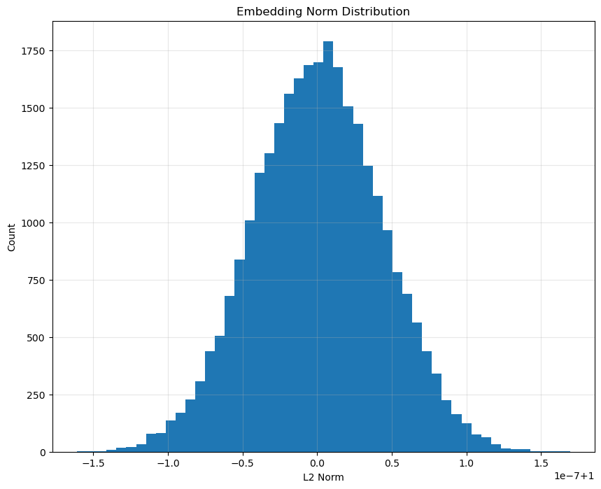

```python
# Quick info about the dataset
print(df_data.info())
#print("\nSample rows:")
#display(df_data[["video_id_short", "filename", "whisper_transcript"]].head())


# Build embedding matrix and inspect norms
X = build_embedding_matrix(df_data, embedding_col="embedding")

# Compute L2 norms as a sanity check
norms = np.linalg.norm(X, axis=1)
print("Embedding norms - min / max / mean:")
print(norms.min(), norms.max(), norms.mean())

plot_histogram(norms, title="Embedding Norm Distribution", xlabel="L2 Norm", bins=50)
```

```python
#filter to niche topics

###RUNTIME is > 10 minutes.

import textwrap
import string
from collections import Counter

##Save a copy of our df_data.
#df_data_backup = df_data.copy(deep=True)
df_data_backup = df_data


# 1. Define Niche Categories
NICHE_KEYWORDS = {
    "Animals": [
        "cat", "dog", "puppy", "kitten", "goat", "pug",
        "screaming", "bark", "scare", "wildlife", "bird"
    ],
    "Humor": [
        "prank", "skit", "pov", "impression", "accent",
        "relatable", "sarcasm", "roast", "savage", "fail",
        "cringe", "awkward", "reaction", "public"
    ],
    "Action_Skills": [
        "parkour", "trickshot", "backflip", "stunt", "wipeout",
        "dunk", "skate", "flip", "magic", "illusion", "juggling"
    ],
    "Music_Audio": [
        "lipsync", "cover", "freestyle", "beatbox", "remix",
        "rap", "singing", "dance", "choreography", "twerk",
        "shuffle", "dubsmash"
    ],
    "Vine_Culture": [
        "loop", "stopmotion", "transition", "edit", "vine",
        "compilation", "challenge", "trend", "viral"
    ],
    "Slang": [
        "yeet", "bruh", "swag", "bae", "thuglife", "mlg",
        "fleek", "goals", "smack", "21"
    ],
    "Relatable_Scenarios": [
        "school", "teacher", "mom", "dad", "sibling",
        "walmart", "car", "drive", "sleep", "wokeuplikethis"
    ],
    "Vine_Meta": [
        "do it for the vine", "i ain’t gon do it", "loop",
        "stop motion", "transition", "6 seconds"
    ]
}

def find_niche_category(transcript: str):
    """
    Returns the specific category name if found, else None.
    Removes punctuation and uses 'whole word' matching.
    """
    if not isinstance(transcript, str) or not transcript.strip():
        return None

    # Lowercase the text
    t = transcript.lower()

    # Replace ALL punctuation with spaces ensuring strings are matched correctly
    for char in string.punctuation:
        t = t.replace(char, " ")

    # Pad with spaces for whole-word search
    t_padded = f" {t} "

    for category, keywords in NICHE_KEYWORDS.items():
        for k in keywords:
            # Check for keyword surrounded by spaces
            if f" {k} " in t_padded:
                return category
    return None

# 2. Apply Categorization
print("Scanning transcripts for keywords...")
df_data["niche_category"] = df_data["whisper_transcript"].apply(find_niche_category)
df_data["is_niche"] = df_data["niche_category"].notna()

# 3. Filter Data
before = len(df_data)
df_filtered = df_data[df_data["is_niche"]].reset_index(drop=True)
after = len(df_filtered)

# Safety Check: Only overwrite if we didn't delete everything
if after > 0:
    df_data = df_filtered
    print(f"→ Niche filtering complete!")
    print(f"   Before : {before:,} videos")
    print(f"   After  : {after:,} videos ({after/before:.1%} kept)\n")
else:
    print("WARNING: Niche filter removed ALL videos. Reverting to full dataset.")

# Stats & Visualization
print("Top matching niche categories:")
print(df_data['niche_category'].value_counts())

# Sample
num_to_show = min(10, len(df_data))
print(f"Sample: up to {num_to_show} random videos ")

# Sample up to 10 videos
subset = df_data.sample(n=min(10, len(df_data)), random_state=42).reset_index(drop=True)

for idx, row in subset.iterrows():
    print(f"\n[{idx+1}] Category: {row['niche_category']}")
    transcript = row.get('whisper_transcript', '')
    if transcript and transcript.strip():
        print(textwrap.fill(transcript.strip(), width=80))
    else:
        print("(no transcript)")


##Now put our data back
#df_data = df_data_backup
#len(df_data)

df = df_data_backup
len(df)
```

```
Scanning transcripts for keywords...
→ Niche filtering complete!
   Before : 28,339 videos
   After  : 894 videos (3.2% kept)

Top matching niche categories:
niche_category
Relatable_Scenarios    460
Music_Audio            124
Animals                111
Vine_Culture            76
Action_Skills           44
Slang                   39
Humor                   39
Vine_Meta                1
Name: count, dtype: int64
Sample: up to 10 random videos

[1] Category: Relatable_Scenarios
Dad see, Supercalifagilistic X-Pialidosius What? Index skillidosios Alright

[2] Category: Relatable_Scenarios
I'm looking cute as hell and I'm like DAD! I'm pizza! You better not talk to
your wife! PEEEEEEEEE!

[3] Category: Music_Audio
Once again to cover entirety myself.

[4] Category: Slang
Let's play 21 questions. Okay, what's your favorite color? Try and go. See you a
version.

[5] Category: Animals
Hey, Ovech! Zimax the dog! Ooooooh! I wish one of you niggas would, still the
fine. Dog gon' make me lose my mind!

[6] Category: Animals
Dude! What? You cat? Died. Don't have a cat? Jeremy? Sike! You should've seen
all the good you've been-

[7] Category: Relatable_Scenarios
Daddy, I got two balls. Are you still have two balls? What happened? I married
your mom.

[8] Category: Relatable_Scenarios
Sorry Mr. Teacher I didn't study for your taste. I'm gonna grow up and shake my
wrist on that pup. You're ready.

[9] Category: Relatable_Scenarios
Dad, you literally have no food. You're so ungrateful, it's free to just both
food.

[10] Category: Animals
Mother cat You know Cheese
```

```
28339
```

## Clustering Analysis - 1

https://medium.com/@RobuRishabh/clustering-text-data-with-k-means-and-visualizing-with-t-sne-9bc1fe7d8fed

```python
df_data.shape
```

```
(894, 9)
```

```python
# Expand the 'Features' column into new columns
expanded_features = df_data['embedding'].apply(pd.Series)

# Optionally, rename the new columns for clarity
expanded_features.columns = [f'embedding_{i+1}' for i in range(expanded_features.shape[1])]

# Concatenate the expanded features with the original DataFrame (excluding the original list column)
df_expanded = pd.concat([expanded_features], axis=1)
```

```python
df_expanded.head()
```

|  | embedding_1 | embedding_2 | embedding_3 | embedding_4 | embedding_5 | embedding_6 | embedding_7 | embedding_8 | embedding_9 | embedding_10 | ... | embedding_759 | embedding_760 | embedding_761 | embedding_762 | embedding_763 | embedding_764 | embedding_765 | embedding_766 | embedding_767 | embedding_768 |
| --- | --- | --- | --- | --- | --- | --- | --- | --- | --- | --- | --- | --- | --- | --- | --- | --- | --- | --- | --- | --- | --- |
| 0 | -0.025081 | 0.029804 | 0.034733 | 0.024596 | -0.039191 | 0.025792 | 0.000619 | -0.034617 | 0.017683 | -0.052607 | ... | -0.022885 | 0.029178 | 0.047175 | -0.029027 | -0.024022 | -0.100388 | -0.000892 | 0.012767 | 0.003885 | 0.030244 |
| 1 | -0.028749 | 0.035381 | 0.023644 | 0.021684 | -0.035363 | 0.023238 | -0.003700 | -0.034115 | 0.014520 | -0.051998 | ... | -0.028071 | 0.023264 | 0.048619 | -0.025296 | -0.020228 | -0.095767 | -0.004211 | 0.016154 | 0.010682 | 0.034759 |
| 2 | -0.029006 | 0.034770 | 0.013127 | 0.023505 | -0.034056 | 0.025917 | -0.002657 | -0.027313 | 0.013899 | -0.045773 | ... | -0.034033 | 0.025358 | 0.044290 | -0.020165 | -0.022959 | -0.091404 | -0.001714 | 0.027133 | 0.007145 | 0.034291 |
| 3 | -0.024376 | 0.029475 | 0.042535 | 0.022767 | -0.038987 | 0.031280 | -0.002504 | -0.038952 | 0.016125 | -0.053613 | ... | -0.020202 | 0.022628 | 0.054915 | -0.028124 | -0.019685 | -0.098421 | -0.004118 | 0.008703 | 0.005089 | 0.032251 |
| 4 | -0.027483 | 0.030626 | 0.024398 | 0.023555 | -0.039849 | 0.023991 | -0.000261 | -0.031850 | 0.017718 | -0.052289 | ... | -0.024424 | 0.030771 | 0.044161 | -0.028048 | -0.023164 | -0.098482 | -0.000586 | 0.018404 | 0.005475 | 0.032272 |

5 rows × 768 columns

```
📦 Found 10 IDs. Displaying first 10.
```

[figure not shown]

```python
display_video_thumbnails(df_data[:10])
```

```
K=5, Inertia=15.103826927707741
K=10, Inertia=9.711049292498412
K=15, Inertia=8.113342584629333
K=20, Inertia=6.802815136227263
K=25, Inertia=6.21642242602187
K=30, Inertia=5.600899475146293
K=35, Inertia=5.167729240654615
K=40, Inertia=4.841550542106575
K=45, Inertia=4.608862065984027
K=50, Inertia=4.270383778465879
K=55, Inertia=4.058889965683354
K=60, Inertia=3.902503146643999
K=65, Inertia=3.767845110101721
K=70, Inertia=3.6067004326865155
K=75, Inertia=3.5071039009617953
K=80, Inertia=3.351022700119341
K=85, Inertia=3.2129577719039366
K=90, Inertia=3.115232270527444
K=95, Inertia=3.010656434373441
K=100, Inertia=2.8974748002557003
K=105, Inertia=2.8221411311138205
K=110, Inertia=2.728808808804053
K=115, Inertia=2.662811696061213
K=120, Inertia=2.6019789847427592
K=125, Inertia=2.5294094093394923
K=130, Inertia=2.4548841876542684
K=135, Inertia=2.4049464255936663
K=140, Inertia=2.3394911057374106
K=145, Inertia=2.2726842016600237
K=150, Inertia=2.20670677855382
K=155, Inertia=2.1479193620978263
K=160, Inertia=2.097812218823908
K=165, Inertia=2.0533285692487806
K=170, Inertia=2.004246688870436
K=175, Inertia=1.9583019694672392
K=180, Inertia=1.9116368272285944
K=185, Inertia=1.8671711540974538
K=190, Inertia=1.8135299527070279
K=195, Inertia=1.779398939217587
```

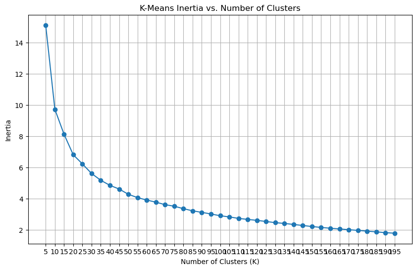

```python
#Perform K-Means with multiple k values to find optimal number of clusters and plot inertia values
from kneed import KneeLocator

###RUNTIME is > 100 minutes.
###RUNTIME is > 11 minutes.

inertia_values = []
k_values = range(5, 200, 5)
for k in k_values:
    kmeans = KMeans(n_clusters=k, random_state=RANDOM_STATE)
    kmeans.fit(df_expanded)
    inertia_values.append(kmeans.inertia_)
    print(f"K={k}, Inertia={kmeans.inertia_}")

kn = KneeLocator(k_values, inertia_values, curve='convex', direction='decreasing')
best_k = kn.knee

# Plot the inertia values to visualize the elbow
plt.figure(figsize=(10, 6))
plt.plot(k_values, inertia_values, marker='o')
plt.title('K-Means Inertia vs. Number of Clusters')
plt.xlabel('Number of Clusters (K)')
plt.ylabel('Inertia')
plt.xticks(k_values)
plt.grid()
plt.show()
```

```python
print('The best K (elbow point) is:', best_k)
```

```
The best K (elbow point) is: 35
```

```python
#Perform K-Means with optimal number of clusters
kmeans = KMeans(n_clusters=best_k, random_state=RANDOM_STATE)
kmeans.fit(df_expanded)
cluster_labels = kmeans.labels_
df_data['cluster_id'] = cluster_labels
```

```python
from sklearn.manifold import TSNE

def reduce_embeddings_tsne(embeddings: np.ndarray, n_components: int = 2, perplexity: float = 30.0, random_state: int = 42):
    # t-SNE can be sensitive to scale; normalize rows to unit length before fitting if needed
    tsne = TSNE(n_components=n_components, perplexity=perplexity, learning_rate='auto',
                init='random', random_state=random_state)
    return tsne.fit_transform(embeddings)
```

```python
#Calculate centroids to identify representative videos from each cluster
centroids = kmeans.cluster_centers_
centroid_indices = []
for i, centroid in enumerate(centroids):
    distances = np.linalg.norm(df_expanded.values - centroid, axis=1)
    closest_index = np.argmin(distances)
    centroid_indices.append(closest_index)
```

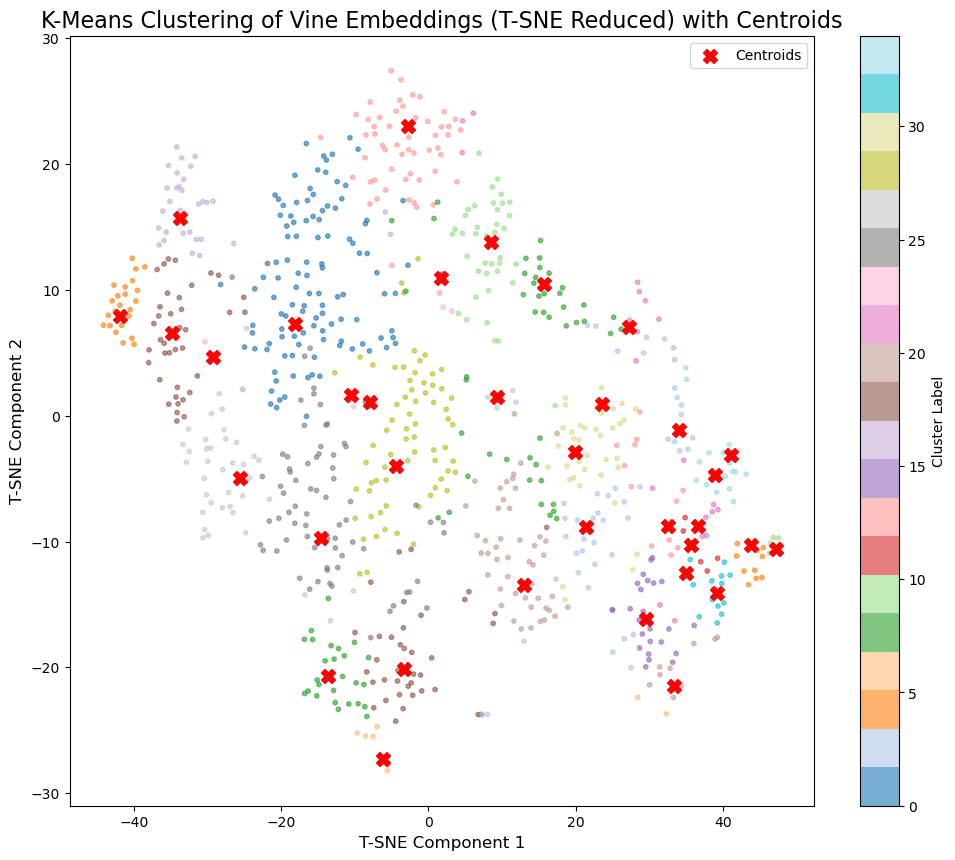

```python
#Plot kmeans data with centroids highlighted

###RUNTIME is > 3 minutes.


reduced_data = reduce_embeddings_tsne(df_expanded)
df_reduced = pd.DataFrame(reduced_data, columns=['TSNE1', 'TSNE2'])
df_reduced['cluster'] = cluster_labels
plt.figure(figsize=FIG_SIZE)
scatter = plt.scatter(df_reduced['TSNE1'], df_reduced['TSNE2'], c=df_reduced['cluster'], s=DOT_SIZE, cmap='tab20', alpha=0.6)
# Highlight centroids
plt.scatter(df_reduced.loc[centroid_indices, 'TSNE1'], df_reduced.loc[centroid_indices, 'TSNE2'],
            c='red', s=100, marker='X', label='Centroids')
plt.title('K-Means Clustering of Vine Embeddings (T-SNE Reduced) with Centroids', fontsize=16)
plt.xlabel('T-SNE Component 1', fontsize=12)
plt.ylabel('T-SNE Component 2', fontsize=12)
plt.colorbar(scatter, label='Cluster Label')
plt.legend()
```

## Vine Selection

```python
#Get the video ids for cluster centroids
centroid_video_ids = df_data.iloc[centroid_indices]['video_id_short'].tolist()
print("Centroid Video IDs:", centroid_video_ids)
```

```
Centroid Video IDs: ['185943AEC2', '13775C1520', '1A95292E0F', '15079F189E', '03C117F7B9', '0DD9712D8C', '0DD4FE5C02', '09E7506481', '070CAEDA25', '026168B7FB', '14D0E0E20B', '1B14F70D7E', '195B78A981', '09AE275A1F', '1795CC8528', '0E4135FF57', '1672F9806F', '1AE7F47D88', '05F3E1D7-A', '01B7FCFEF5',…
```

```
📦 Found 35 IDs. Displaying first 35.
```

[figure not shown]

```python
vines_to_use = df_data[df_data['video_id_short'].isin(centroid_video_ids)]

len(vines_to_use)

display_video_thumbnails(vines_to_use,50)
```

## Cluster Analysis - 2

```
📦 Found 15 IDs. Displaying first 15.
```

[figure not shown]

```python
display_video_thumbnails(df_data[:15])
```

```python
##Clustering & Niche Scoping
#K-Means Clustering

kmeans = run_kmeans(X, n_clusters=N_CLUSTERS, random_state=RANDOM_STATE)

# Add cluster labels to DataFrame
df["cluster_id"] = kmeans.labels_
df["cluster_id"].value_counts().head()
```

```
Running K-Means with k=50...
K-Means completed.
```

```
cluster_id
13    1259
4     1216
34    1215
21    1214
17    1178
Name: count, dtype: int64
```

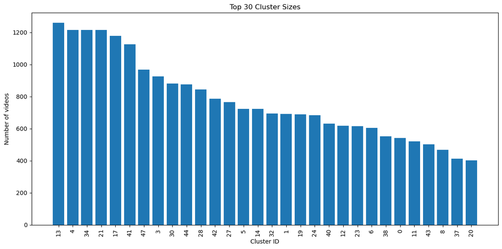

```python
##Cluster Size Summary & Plot

cluster_summary = summarize_clusters(df, cluster_col="cluster_id")
cluster_summary.head(10)

plot_cluster_size_bar(cluster_summary, top_k=30)
```

```
t-SNE on subsample of 3000 points out of 28339.
t-SNE completed.
```

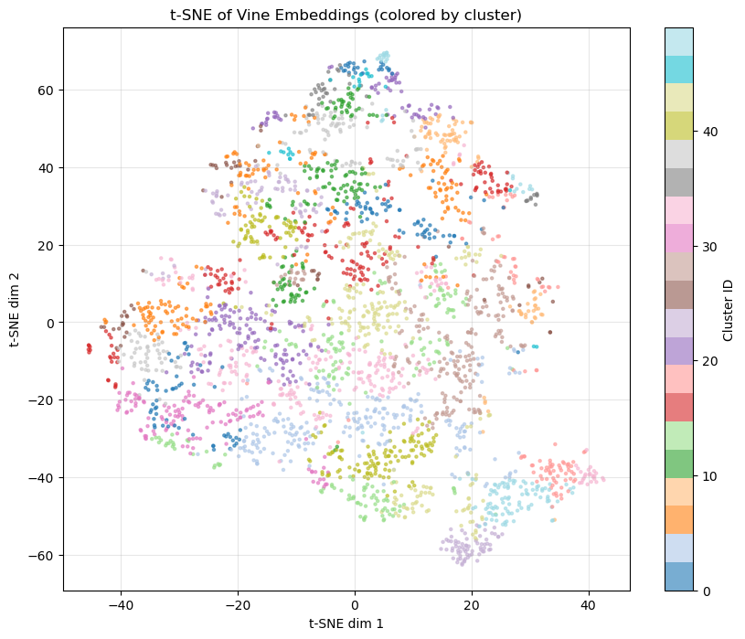

```python
#t-SNE Visualization
coords_2d, tsne_indices = run_tsne(X, max_points=MAX_TSNE_POINTS, perplexity=TSNE_PERPLEXITY)

#Align labels for the subsample used in t-SNE
tsne_labels = df.iloc[tsne_indices]["cluster_id"].values

plot_tsne_scatter(coords_2d, labels=tsne_labels, title="t-SNE of Vine Embeddings (colored by cluster)")
```

```python
##Manual Niche Exploration Helper
##We’ll make a helper to inspect random examples from a cluster so we can pick a niche.

import textwrap

def sample_cluster_examples(df: pd.DataFrame, cluster_id: int, n: int = 10, random_seed: int = RANDOM_SEED):
    """
    Print sample metadata (and transcripts) from a given cluster.

    Args:
        df: Full DataFrame containing 'cluster_id'.
        cluster_id: Which cluster to inspect.
        n: Number of random examples to show.
    """
    subset = df[df["cluster_id"] == cluster_id]
    print(f"Cluster {cluster_id} contains {len(subset)} videos.")
    if len(subset) == 0:
        return

    n = min(n, len(subset))
    subset = subset.sample(n, random_state=random_seed)

    for i, row in subset.iterrows():
        print("=" * 80)
        print(f"Index: {i}")
        print(f"video_id_short: {row['video_id_short']}")
        print(f"filename: {row['filename']}")
        lang = row.get("whisper_language", None)
        if lang:
            print(f"whisper_language: {lang}")
        transcript = row.get("whisper_transcript", "")
        if isinstance(transcript, str) and transcript.strip():
            wrapped = textwrap.fill(transcript, width=70)
            print("whisper_transcript:")
            print(wrapped)
        else:
            print("whisper_transcript: [None]")


# Example: explore a few clusters manually
for cid in cluster_summary.head(10)["cluster_id"]:
    print(f"\n\n>>> SAMPLE FROM CLUSTER {cid}")
    sample_cluster_examples(df, cluster_id=cid, n=5)
```

```
>>> SAMPLE FROM CLUSTER 13
Cluster 13 contains 1259 videos.
================================================================================
Index: 2769
video_id_short: 0CE70B7C39
filename: 20140305031521_0CE70B7C391033381255921983488_138935129688762801f11d4.mp4_XEjiPSV9DAMR5DoIt7yk5amxrkBizs0yPnlfcGkMDdu7ww4055.6PwkIJFOxvr2r.mp4.mp4
whisper_language: ko
whisper_transcript: [None]
================================================================================
Index: 10256
video_id_short: 0866B1DB8A
filename: 20141207012716_0866B1DB8A1089156907123503104_265c1044e1b.0.4.6057099010565781285.mp4.mp4
whisper_language: ja
whisper_transcript: [None]
================================================================================
Index: 11906
video_id_short: 010ACE2A99
filename: 20150531175113_010ACE2A991109221884677029888_26ccbebdd7e.2.1.14962500560982813870.mp4.mp4
whisper_language: tr
whisper_transcript: [None]
================================================================================
Index: 12906
video_id_short: 1177CC0236
filename: 20150723220815_1177CC02361078335967230038016_28dd8344f84.0.2.16029010393930958214.mp4.mp4
whisper_language: en
whisper_transcript:
Never too early for a pint, right boys? It is 9am, you have a problem.
================================================================================
Index: 11675
video_id_short: 05ED931EAC
filename: 20150407150659_05ED931EAC1196923901171937280_32a8f27bbeb.2.1.2403888722162811060.mp4.mp4
whisper_language: en
whisper_transcript:
That is driven to deep lab garden. Mark is sharp.


>>> SAMPLE FROM CLUSTER 4
Cluster 4 contains 1216 videos.
================================================================================
Index: 7855
```

[output cut: 336 more lines]

```
video_id_short: 168E6C2B46
filename: 20150603085233_168E6C2B461216946849756884992_32437f21cfb.3.3.7603343267941192389.mp4.mp4
whisper_language: en
whisper_transcript:
If there is nothing going on this whole area from disease chrome先生 beg
for exact, the way theyajopewew acopl我们全力的魔bay I don't know what would
happen to the mic drive it do not drive 😘 I just actually made a
mistake
================================================================================
Index: 1384
video_id_short: 1AFDEBBB48
filename: 20140222121323_1AFDEBBB48996707734713946112_13fc2d33a09.3.4_oV6wX1IXmIRSqpHNtVSwblL7sYJk6nXVXLtxSJkMKiZmz4bPnP0gNclLqXDZYNWs.mp4.mp4
whisper_language: en
whisper_transcript:
We're sleeping in the space from the wind inside your
```

```python
##List out a few thumbnails.

thumb_dir = Path(THUMBNAIL_BASE_DIR)
list(thumb_dir.iterdir())[:20]

#df[df["cluster_id"] == 4]["thumbnail_path"].head(5).tolist()
```

```
[WindowsPath('E:/UtKnox/Courses/Fall_2025/COSC545 - Digital Archeology/Module_7/Team Project/Data/thumbs/00DE549D20.png'),
 WindowsPath('E:/UtKnox/Courses/Fall_2025/COSC545 - Digital Archeology/Module_7/Team Project/Data/thumbs/00DE66AB54.png'),
 WindowsPath('E:/UtKnox/Courses/Fall_2025/COSC545 - Digital Archeology/Module_7/Team Project/Data/thumbs/00DEE816AE.png'),
 WindowsPath('E:/UtKnox/Courses/Fall_2025/COSC545 - Digital Archeology/Module_7/Team Project/Data/thumbs/00DEF2A5BA.png'),
 WindowsPath('E:/UtKnox/Courses/Fall_2025/COSC545 - Digital Archeology/Module_7/Team Project/Data/thumbs/00DF2D1D65.png'),
 WindowsPath('E:/UtKnox/Courses/Fall_2025/COSC545 - Digital Archeology/Module_7/Team Project/Data/thumbs/00E009D808.png'),
 WindowsPath('E:/UtKnox/Courses/Fall_2025/COSC545 - Digital Archeology/Module_7/Team Project/Data/thumbs/00E03ABF48.png'),
 WindowsPath('E:/UtKnox/Courses/Fall_2025/COSC545 - Digital Archeology/Module_7/Team Project/Data/thumbs/00E0713623.png'),
 WindowsPath('E:/UtKnox/Courses/Fall_2025/COSC545 - Digital Archeology/Module_7/Team Project/Data/thumbs/00E0D97D61.png'),
 WindowsPath('E:/UtKnox/Courses/Fall_2025/COSC545 - Digital Archeology/Module_7/Team Project/Data/thumbs/00E11A941B.png'),
 WindowsPath('E:/UtKnox/Courses/Fall_2025/COSC545 - Digital Archeology/Module_7/Team Project/Data/thumbs/00E11B5C20.png'),
 WindowsPath('E:/UtKnox/Courses/Fall_2025/COSC545 - Digital Archeology/Module_7/Team Project/Data/thumbs/00E12214FE.png'),
 WindowsPath('E:/UtKnox/Courses/Fall_2025/COSC545 - Digital Archeology/Module_7/Team Project/Data/thumbs/00E13E98CC.png'),
 WindowsPath('E:/UtKnox/Courses/Fall_2025/COSC545 - Digital Archeology/Module_7/Team Project/Data/thumbs/00E16BC806.png'),
 WindowsPath('E:/UtKnox/Courses/Fall_2025/COSC545 - Digital Archeology/Module_7/Team Project/Data/thumbs/00E1AE6AE1.png'),
 WindowsPath('E:/UtKnox/Courses/Fall_2025/COSC545 - Digital Archeology/Module_7/Team Project/Data/thumbs/00E20E1D20.png'),
 WindowsPath('E:/UtKnox/Courses/Fall_2025/COSC545 - Digital Archeology/Module_7/Team Project/Data/thumbs/00E23EF727.png'),
 WindowsPath('E:/UtKnox/Courses/Fall_2025/COSC545 - Digital Archeology/Module_7/Team Project/Data/thumbs/00E27E0E17.png'),
 WindowsPath('E:/UtKnox/Courses/Fall_2025/COSC545 - Digital Archeology/Module_7/Team Project/Data/thumbs/00E2DCB4AD.png'),
 WindowsPath('E:/UtKnox/Courses/Fall_2025/COSC545 - Digital Archeology/Module_7/Team Project/Data/thumbs/00E3F03246.png')]
```

```python
###TIMINGS > 35 minutes.

###Detect additional possible NSFW content.

THUMB_DIR = Path(THUMBNAIL_BASE_DIR)  ##use our existing variable

df_nsfw_scores = scan_thumbnails_for_nsfw_batched(
    THUMB_DIR,
    exts=(".png",),
    unsafe_threshold=0.80,
    batch_size=256
)

# df_nsfw_scores.head(20)
```

```python
##To see just the flagged filenames:

##Get flagged filenames (to remove from our dataset):
#flagged = df_nsfw[df_nsfw["flagged"]]

flagged = df_nsfw_scores[df_nsfw_scores["flagged"]]
flagged_paths = flagged["path"].tolist()

print("Flagged thumbnails:")
for p in flagged_paths:
    print(p)
```

```
Flagged thumbnails:
E:\UtKnox\Courses\Fall_2025\COSC545 - Digital Archeology\Module_7\Team Project\Data\thumbs\17CC5F7BBC.png
E:\UtKnox\Courses\Fall_2025\COSC545 - Digital Archeology\Module_7\Team Project\Data\thumbs\135F37BDF3.png
E:\UtKnox\Courses\Fall_2025\COSC545 - Digital Archeology\Module_7\Team Project\Data\thumbs\0D6D530019.png
E:\UtKnox\Courses\Fall_2025\COSC545 - Digital Archeology\Module_7\Team Project\Data\thumbs\12DC0C8DD9.png
E:\UtKnox\Courses\Fall_2025\COSC545 - Digital Archeology\Module_7\Team Project\Data\thumbs\1AC22C9EAF.png
E:\UtKnox\Courses\Fall_2025\COSC545 - Digital Archeology\Module_7\Team Project\Data\thumbs\144FA209BA.png
E:\UtKnox\Courses\Fall_2025\COSC545 - Digital Archeology\Module_7\Team Project\Data\thumbs\093C7BE499.png
```

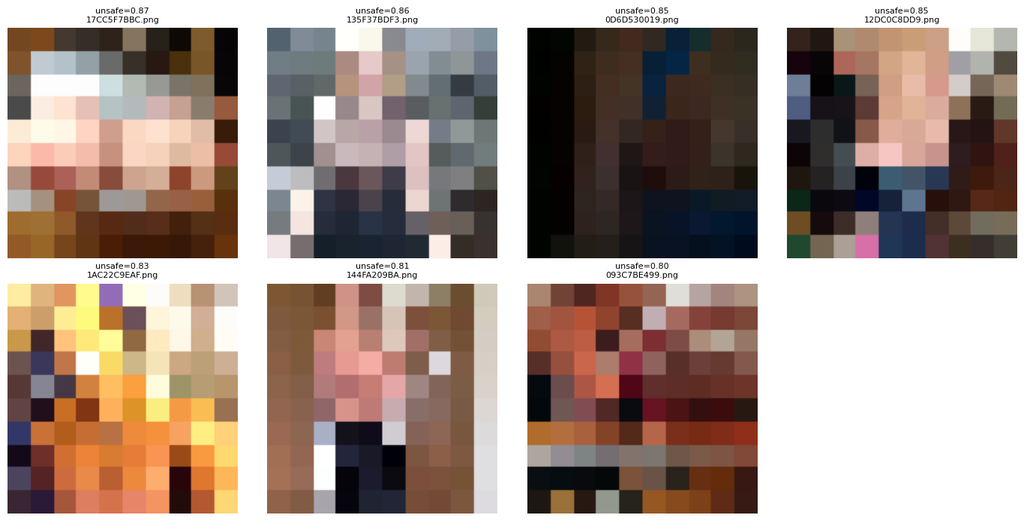

```python
##Display the most suspicious thumbnail images for manual confirmation:

#display_flagged_images(df_nsfw_scores, n=16, cols=4)

##Blurred OFFENSIVE thumbnail images
#display_flagged_images_censored(df_nsfw_scores, n=16, cols=4, mode="blur")

##Pixelated OFFENSIVE thumbnail images.
display_flagged_images_censored(df_nsfw_scores, n=16, cols=4, mode="pixelate")
```

```python
##Call our helper function to add thumbnail paths to the DataFrame.

##Looks at each row’s filename
##Computes a likely thumbnail name (e.g., .jpg, .png)
##Adds a thumbnail_path column to df

df = add_thumbnail_paths(
    df,
    THUMBNAIL_BASE_DIR,
    filename_col="filename",
    thumb_col="thumbnail_path"
)

#df.columns
```

```
Cluster 19 has 689 items.
```

[figure not shown]

```python
##Display some thumbnails from a specific cluster.
##Rather manual intensive & tedious, but gives us great visibility
##and insight on our various clusters to overall help us with
##our niche selection.


#show_cluster_thumbnails (df,1)
#show_cluster_thumbnails(df, cluster_id=4, n=12, thumb_col="thumbnail_path")


##Let's manually take a look a some actualy images from the clusters.  Overall, its
##a rather tedious process, but may prove beneficial.
##We'll choose a number above the required 50 - like 60, or 70, or greater. Doing so will allow us
##to later exclude a thumbnail that maybe misaligned with our overall "niche".

#show_cluster_thumbnails_matplotlib(df, cluster_id=3, n=80)
#show_cluster_thumbnails_matplotlib(df, cluster_id=4, n=80)
#show_cluster_thumbnails_matplotlib(df, cluster_id=18, n=80)
#show_cluster_thumbnails_matplotlib(df, cluster_id=10, n=80)

##Below are a group of Possible candidate for our team;  mostly showing performers
##(singers/musicicians, etc) ...like Grande, Bieber, Beyonce, etc.
#show_cluster_thumbnails_matplotlib(df, cluster_id=11, n=500)
#show_cluster_thumbnails_matplotlib(df, cluster_id=42, n=80)
#show_cluster_thumbnails_matplotlib(df, cluster_id=26, n=80)



#show_cluster_thumbnails_matplotlib(df, cluster_id=28, n=80)


#show_cluster_thumbnails_matplotlib(df, cluster_id=0, n=10)
show_cluster_thumbnails_matplotlib(df, cluster_id=19, n=80)
#show_cluster_thumbnails_matplotlib(df, cluster_id=21, n=80)

# for cluster_id in range(51):
#     print(f"Showing thumbnails for cluster {cluster_id}")
#     show_cluster_thumbnails_matplotlib(df, cluster_id=cluster_id, n=10)
#     print("-" * 40)
```

```python
##Our specific/selected niche cluster id, after exploring many clusters.
TARGET_CLUSTER_ID = 19

df_niche = df[df["cluster_id"] == TARGET_CLUSTER_ID].copy()
len(df_niche)
```

[output not shown]

[figure not shown]

```python
##Compute centroid of the niche in embedding space
niche_indices = df_niche.index.values
X_niche = X[niche_indices]

niche_centroid = X_niche.mean(axis=0)
niche_distances = np.linalg.norm(X_niche - niche_centroid, axis=1)

df_niche["distance_to_centroid"] = niche_distances
df_niche[["video_id_short", "distance_to_centroid"]].head()


plot_histogram(
    df_niche["distance_to_centroid"],
    title=f"Distance to Niche Centroid (Cluster {TARGET_CLUSTER_ID})",
    xlabel="L2 distance",
    bins=40,
)
```

## Manual Cluster Thumbnail Inspection/Selection

```python
manual_thumbnail_order_ids = [
    "10FF494F70",   ##Female start here
    "01367FCCCF",
    "12251AA858",
    "06BF37F323",
    "05F527E2A5",
    "18C12F9ED8",
    "01A24EB36A",
    "0B073FDAB3",
    "132EA6617B",
    "021791D54A",   ##10
    "055A00AF04",
    "03D9282FEE",
    "09B95BADEF",
    "04A29FB000",
    "15C0F3CDC2",
    "0ED5C769BF",
    "05B97FBA3C",
    "0C1A08F7DF",
    "115CB6C89A",
    "01C94F3501",  ##20  Male start here
    "1BD6ECA2B8",
    "0856C85180",
    "0F55B549AB",
    "0842710079",
    "1110D9BE80",
    "0B92C2142A",
    "0CEE95F401",
    "0865EDDF86",
    "0D43FE244D",
    "093ECD5401",  ##30
    "17D85539FB",
    "0168C5B5F4",   ##Female performers starts here
    "1D0BDBE93B",
    "107DF527B2",
    "163FCBE821",
    "1AE666BC91",
    "09C0942D1F",
    "04A5705FD4",
    "08A60BA7F0",
    "1A03A4F855",   ##40
    "1C461CE862",
    "0DA1ECD1EF",
    "0107857B0A",  ##Male performers starts here
    "09FF3488C1",
    "18FC6DCC52",
    "1C1FEB0FF2",
    "1AAC5E2CA0",
    "02C68A3135",
    "10A4AD7AE5",
    "16175F97E3", ##50
]
```

### Convert into our final list of videos dataframe

```python
##filter the entire dataframe by our manual ID list, then enforce our manual order.


manual_ids = manual_thumbnail_order_ids
cluster_summary = summarize_manual_cluster_membership(df, manual_ids)
cluster_summary



##Filter from FULL df, not a cluster slice
df_manual = df[df["video_id_short"].isin(manual_ids)].copy()

##Enforce manual order
order_map = {vid: i for i, vid in enumerate(manual_ids)}
df_manual["manual_rank"] = df_manual["video_id_short"].map(order_map)

df_final = df_manual.sort_values("manual_rank").reset_index(drop=True)

df_final[["manual_rank", "video_id_short"]].head(10)

#len(df_final)
```

```
=== Manual Selection Cluster Distribution ===
Cluster 3: 1 videos
Cluster 19: 37 videos
Cluster 33: 1 videos
Cluster 47: 11 videos
```

|  | manual_rank | video_id_short |
| --- | --- | --- |
| 0 | 0 | 10FF494F70 |
| 1 | 1 | 01367FCCCF |
| 2 | 2 | 12251AA858 |
| 3 | 3 | 06BF37F323 |
| 4 | 4 | 05F527E2A5 |
| 5 | 5 | 18C12F9ED8 |
| 6 | 6 | 01A24EB36A |
| 7 | 7 | 0B073FDAB3 |
| 8 | 8 | 132EA6617B |
| 9 | 9 | 021791D54A |

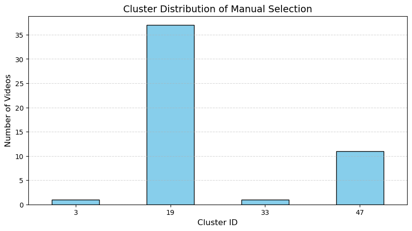

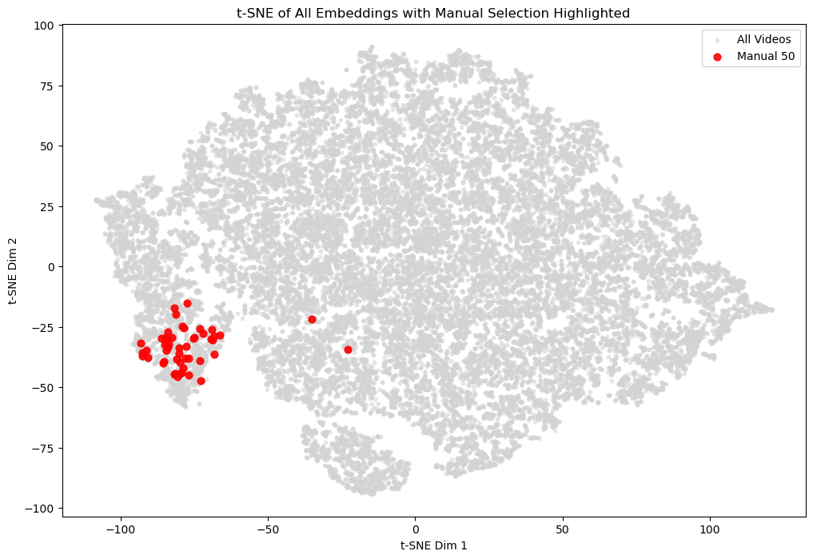

```python
####RUNTIME > 4 minutes.

##Manual plots:

#Bar Chart:
#Shows clearly how clusters “shifted” after reclustering


#t-SNE Plot:
#Shows where our chosen videos live in the embedding space
#Highlights how our 50 picks occupy a semantic subregion


plot_manual_cluster_bar(df, manual_thumbnail_order_ids)
plot_tsne_with_manual_highlight(df, manual_thumbnail_order_ids)
```

### Validate our Manual Selection

```python
###Make sure they are all there.
#------------------------------------------------
#11.3 Validation checks (missing IDs, duplicates, final count)
#------------------------------------------------

expected = len(manual_thumbnail_order_ids)
actual = len(df_final)

missing_ids = [vid for vid in manual_thumbnail_order_ids
               if vid not in df_final["video_id_short"].values]

duplicates = pd.Series(manual_thumbnail_order_ids).duplicated()
dup_ids = pd.Series(manual_thumbnail_order_ids)[duplicates].tolist()

print("--------------------------------------------------")
print(f"Expected manual IDs: {expected}")
print(f"Found in df_final:   {actual}")
print(f"Duplicate IDs in manual list: {len(dup_ids)}")
print("--------------------------------------------------")

if dup_ids:
    print("WARNING: Duplicate IDs detected in manual order list:")
    for d in dup_ids:
        print("  -", d)



if missing_ids:
    print("\nWARNING: Missing IDs in current df:")
    for m in missing_ids:
        print("  -", m)

# Show all 50 full paths/IDs once video_path is built
df_final[["manual_rank", "video_id_short", "thumbnail_path"]].head(10)
```

```
--------------------------------------------------
Expected manual IDs: 50
Found in df_final:   50
Duplicate IDs in manual list: 0
--------------------------------------------------
```

|  | manual_rank | video_id_short | thumbnail_path |
| --- | --- | --- | --- |
| 0 | 0 | 10FF494F70 | E:\UtKnox\Courses\Fall_2025\COSC545 - Digital ... |
| 1 | 1 | 01367FCCCF | E:\UtKnox\Courses\Fall_2025\COSC545 - Digital ... |
| 2 | 2 | 12251AA858 | E:\UtKnox\Courses\Fall_2025\COSC545 - Digital ... |
| 3 | 3 | 06BF37F323 | E:\UtKnox\Courses\Fall_2025\COSC545 - Digital ... |
| 4 | 4 | 05F527E2A5 | E:\UtKnox\Courses\Fall_2025\COSC545 - Digital ... |
| 5 | 5 | 18C12F9ED8 | E:\UtKnox\Courses\Fall_2025\COSC545 - Digital ... |
| 6 | 6 | 01A24EB36A | E:\UtKnox\Courses\Fall_2025\COSC545 - Digital ... |
| 7 | 7 | 0B073FDAB3 | E:\UtKnox\Courses\Fall_2025\COSC545 - Digital ... |
| 8 | 8 | 132EA6617B | E:\UtKnox\Courses\Fall_2025\COSC545 - Digital ... |
| 9 | 9 | 021791D54A | E:\UtKnox\Courses\Fall_2025\COSC545 - Digital ... |

## Compilation Creation

### Build actual video paths

```python
# 8 – Export Plan (FFmpeg / MoviePy-Friendly Output)
#8.1 Generate list of filenames in order



# ------------------------------------------------
# 11.4 Build actual video paths from video_id_short + ".mp4"
#      Track missing video files and report total
# ------------------------------------------------

# This assumes our actual video files are accessible using 'filename' field
# and a base directory VIDEO_BASE_DIR that we define below.
VIDEO_BASE_DIR = Path("E:/UtKnox/Courses/Fall_2025/COSC545 - Digital Archeology/Module_7/Team Project/Data/vidthumbs")

# Globals to track missing video files
MISSING_VIDEO_FILES = []
MISSING_COUNT = 0


def get_video_path(row) -> Path:
    """
    Build actual video path from video_id_short.
    Track missing files.
    """
    global MISSING_COUNT, MISSING_VIDEO_FILES

    filename = f"{row['video_id_short']}.thumb.mp4"
    full_path = VIDEO_BASE_DIR / filename

    if not full_path.exists():
        MISSING_COUNT += 1
        MISSING_VIDEO_FILES.append(full_path)

    return full_path


# Reset counters before running
MISSING_VIDEO_FILES = []
MISSING_COUNT = 0

df_final["video_path"] = df_final.apply(get_video_path, axis=1)


print("--------------------------------------------------")
print(f"Total videos expected: {len(df_final)}")
print(f"Video files NOT FOUND: {MISSING_COUNT}")
print("--------------------------------------------------")

if MISSING_COUNT > 0:
    print("List of missing files:")
    for p in MISSING_VIDEO_FILES:
        print("  -", p)



#df_final[["video_id_short", "video_path"]].head()


##Print out the names of our 50 video files.
for vid, path in df_final[["video_id_short", "video_path"]].values:
    print(f"{vid}: {path}")



##Save our final 50 video ID's to a CSV file.
df_final[["video_id_short", "video_path"]].to_csv(
    "vine_final_video_paths.csv",
    index=False
)
print("Saved as vine_final_video_paths.csv")
```

```
--------------------------------------------------
Total videos expected: 50
Video files NOT FOUND: 0
--------------------------------------------------
10FF494F70: E:\UtKnox\Courses\Fall_2025\COSC545 - Digital Archeology\Module_7\Team Project\Data\vidthumbs\10FF494F70.thumb.mp4
01367FCCCF: E:\UtKnox\Courses\Fall_2025\COSC545 - Digital Archeology\Module_7\Team Project\Data\vidthumbs\01367FCCCF.thumb.mp4
12251AA858: E:\UtKnox\Courses\Fall_2025\COSC545 - Digital Archeology\Module_7\Team Project\Data\vidthumbs\12251AA858.thumb.mp4
06BF37F323: E:\UtKnox\Courses\Fall_2025\COSC545 - Digital Archeology\Module_7\Team Project\Data\vidthumbs\06BF37F323.thumb.mp4
05F527E2A5: E:\UtKnox\Courses\Fall_2025\COSC545 - Digital Archeology\Module_7\Team Project\Data\vidthumbs\05F527E2A5.thumb.mp4
18C12F9ED8: E:\UtKnox\Courses\Fall_2025\COSC545 - Digital Archeology\Module_7\Team Project\Data\vidthumbs\18C12F9ED8.thumb.mp4
01A24EB36A: E:\UtKnox\Courses\Fall_2025\COSC545 - Digital Archeology\Module_7\Team Project\Data\vidthumbs\01A24EB36A.thumb.mp4
0B073FDAB3: E:\UtKnox\Courses\Fall_2025\COSC545 - Digital Archeology\Module_7\Team Project\Data\vidthumbs\0B073FDAB3.thumb.mp4
132EA6617B: E:\UtKnox\Courses\Fall_2025\COSC545 - Digital Archeology\Module_7\Team Project\Data\vidthumbs\132EA6617B.thumb.mp4
021791D54A: E:\UtKnox\Courses\Fall_2025\COSC545 - Digital Archeology\Module_7\Team Project\Data\vidthumbs\021791D54A.thumb.mp4
055A00AF04: E:\UtKnox\Courses\Fall_2025\COSC545 - Digital Archeology\Module_7\Team Project\Data\vidthumbs\055A00AF04.thumb.mp4
03D9282FEE: E:\UtKnox\Courses\Fall_2025\COSC545 - Digital Archeology\Module_7\Team Project\Data\vidthumbs\03D9282FEE.thumb.mp4
09B95BADEF: E:\UtKnox\Courses\Fall_2025\COSC545 - Digital Archeology\Module_7\Team Project\Data\vidthumbs\09B95BADEF.thumb.mp4
04A29FB000: E:\UtKnox\Courses\Fall_2025\COSC545 - Digital Archeology\Module_7\Team Project\Data\vidthumbs\04A29FB000.thumb.mp4
15C0F3CDC2: E:\UtKnox\Courses\Fall_2025\COSC545 - Digital Archeology\Module_7\Team Project\Data\vidthumbs\15C0F3CDC2.thumb.mp4
0ED5C769BF: E:\UtKnox\Courses\Fall_2025\COSC545 - Digital Archeology\Module_7\Team Project\Data\vidthumbs\0ED5C769BF.thumb.mp4
05B97FBA3C: E:\UtKnox\Courses\Fall_2025\COSC545 - Digital Archeology\Module_7\Team Project\Data\vidthumbs\05B97FBA3C.thumb.mp4
0C1A08F7DF: E:\UtKnox\Courses\Fall_2025\COSC545 - Digital Archeology\Module_7\Team Project\Data\vidthumbs\0C1A08F7DF.thumb.mp4
115CB6C89A: E:\UtKnox\Courses\Fall_2025\COSC545 - Digital Archeology\Module_7\Team Project\Data\vidthumbs\115CB6C89A.thumb.mp4
01C94F3501: E:\UtKnox\Courses\Fall_2025\COSC545 - Digital Archeology\Module_7\Team Project\Data\vidthumbs\01C94F3501.thumb.mp4
1BD6ECA2B8: E:\UtKnox\Courses\Fall_2025\COSC545 - Digital Archeology\Module_7\Team Project\Data\vidthumbs\1BD6ECA2B8.thumb.mp4
0856C85180: E:\UtKnox\Courses\Fall_2025\COSC545 - Digital Archeology\Module_7\Team Project\Data\vidthumbs\0856C85180.thumb.mp4
0F55B549AB: E:\UtKnox\Courses\Fall_2025\COSC545 - Digital Archeology\Module_7\Team Project\Data\vidthumbs\0F55B549AB.thumb.mp4
0842710079: E:\UtKnox\Courses\Fall_2025\COSC545 - Digital Archeology\Module_7\Team Project\Data\vidthumbs\0842710079.thumb.mp4
1110D9BE80: E:\UtKnox\Courses\Fall_2025\COSC545 - Digital Archeology\Module_7\Team Project\Data\vidthumbs\1110D9BE80.thumb.mp4
0B92C2142A: E:\UtKnox\Courses\Fall_2025\COSC545 - Digital Archeology\Module_7\Team Project\Data\vidthumbs\0B92C2142A.thumb.mp4
0CEE95F401: E:\UtKnox\Courses\Fall_2025\COSC545 - Digital Archeology\Module_7\Team Project\Data\vidthumbs\0CEE95F401.thumb.mp4
0865EDDF86: E:\UtKnox\Courses\Fall_2025\COSC545 - Digital Archeology\Module_7\Team Project\Data\vidthumbs\0865EDDF86.thumb.mp4
0D43FE244D: E:\UtKnox\Courses\Fall_2025\COSC545 - Digital Archeology\Module_7\Team Project\Data\vidthumbs\0D43FE244D.thumb.mp4
093ECD5401: E:\UtKnox\Courses\Fall_2025\COSC545 - Digital Archeology\Module_7\Team Project\Data\vidthumbs\093ECD5401.thumb.mp4
17D85539FB: E:\UtKnox\Courses\Fall_2025\COSC545 - Digital Archeology\Module_7\Team Project\Data\vidthumbs\17D85539FB.thumb.mp4
0168C5B5F4: E:\UtKnox\Courses\Fall_2025\COSC545 - Digital Archeology\Module_7\Team Project\Data\vidthumbs\0168C5B5F4.thumb.mp4
```

[output cut: 19 more lines]

### Our compilation into a printable storyboard (grid) + save to a PNG file on disk

```
Storyboard saved to: E:\UtKnox\Courses\Fall_2025\COSC545 - Digital Archeology\Module_7\Team Project\GP\vine_storyboard_cluster11_manual.png
```

[figure not shown]

```python
##Time for our storyboard of our selected images.

def make_storyboard(df_final: pd.DataFrame,
                    thumb_col: str = "thumbnail_path",
                    id_col: str = "video_id_short",
                    cols: int = 10,
                    figsize_per_thumb: float = 2.0,
                    save_path: Path = None):
    """
    Create a storyboard grid in manual order.
    Optionally save to PNG if save_path provided.

    Args:
        df_final: ordered final dataframe
        thumb_col: thumbnail path column
        id_col: ID column (used for labels)
        cols: number of columns in grid
        figsize_per_thumb: scale factor for figure size
        save_path: if not None, save figure to this path (PNG)
    """
    n = len(df_final)
    rows = math.ceil(n / cols)
    fig_w = cols * figsize_per_thumb
    fig_h = rows * figsize_per_thumb

    plt.figure(figsize=(fig_w, fig_h))

    for i, (_, row) in enumerate(df_final.iterrows(), start=1):
        plt.subplot(rows, cols, i)
        plt.axis("off")

        p = Path(row[thumb_col])
        vid = row[id_col]

        if p.exists():
            try:
                img = Image.open(p).convert("RGB")
                plt.imshow(img)
            except Exception:
                plt.text(0.5, 0.5, "Bad image", ha="center", va="center")
        else:
            plt.text(0.5, 0.5, "Missing thumb", ha="center", va="center")

        plt.title(f"{i}. {vid}", fontsize=7)

    plt.tight_layout()

    if save_path is not None:
        save_path = Path(save_path)
        plt.savefig(save_path, dpi=200, bbox_inches="tight")
        print(f"Storyboard saved to: {save_path.resolve()}")

    plt.show()

# Display storyboard and save a PNG version
storyboard_png_path = Path("vine_storyboard_cluster11_manual.png")
make_storyboard(df_final, cols=10, figsize_per_thumb=2.0, save_path=storyboard_png_path)
```

### Compile similar img files for Final Vine compilation video

```python
##FFmpeg concat file creation from df_final

#df_final["video_id_short"].tolist()


def generate_ffmpeg_concat_file(df_final: pd.DataFrame, output_txt_path: Path) -> None:
    """
    Generate a concat text file for ffmpeg based on df_final.

    Each line will look like:
        file '/full/path/to/video.mp4' or file '/full/path/to/video.thumb.mp4' or

    then run:
        ffmpeg -f concat -safe 0 -i concat_list.txt -c copy output_compilation.mp4
    """
    lines = []
    for _, row in df_final.iterrows():
        path_str = str(row["video_path"])
        lines.append(f"file '{path_str}'\n")

    output_txt_path = Path(output_txt_path)
    with output_txt_path.open("w", encoding="utf-8") as f:
        f.writelines(lines)

    print(f"FFmpeg concat file written to: {output_txt_path}")


concat_list_path = Path("vine_compilation_concat_list.txt")
generate_ffmpeg_concat_file(df_final, concat_list_path)
```

```
FFmpeg concat file written to: vine_compilation_concat_list.txt
```

### FFmpeg comand to create final vine video ( run on our native OS - Windows or Linux/Mac)

Once `vine_compilation_concat_list.txt` is generated, we can use:

```
ffmpeg -f concat -safe 0 -i vine_compilation_concat_list.txt \
       -c copy \
       vine_compilation_output.mp4
```

## Reflection Section

The selection process for our Vine compilation project reflects a hybrid methodology that combines computational clustering with human-guided interpretive decision-making. While the initial grouping of Vine content was informed through video embeddings, allowing high-dimensional similarity patterns to surface naturally, our final thematic direction emerged through manual/iterative visual exploration. The embedding model helped identify a cohesive entertainment focused cluster with numerous examples of on-stage performances, backstage footage, music video fragments, and performer close ups. This computational assistance provided an efficient starting point for us, narrowing thousands of Vine clips into a manageable subset aligned with recognizable motifs in musical entertainment.

However, the computational clustering alone was insufficient for determining narrative relevance, emotional tone, or thematic focus. The provided transcript fields, despite being automatically generated, did not offer meaningful discriminative value for distinguishing between subtypes of entertainment content. Many performances lacked speech or contained only ambient noise, making embeddings and audio fragments minimally informative. Thus, our project necessitated a qualitative layer of interpretation where thumbnails were examined visually to assess pose, facial expression, performance context, and stylistic cues associated with performance oriented identity. So the computational models help identify patterns, augmented by our research to determine meaning.

Our chosen thematic and narrative direction emphasized mostly performers; especially singers, rather than general actors or dancers - though some were present. Through visual inspection, differences emerged between stage performance scenes, music video like moments, and studio or interview settings. This interpretive process underscored the importance of human judgment to refine the initial computational grouping. The result is a focal theme centered on entertainers, with a subtheme that highlights emotional intimacy, artistic presence, and the personal identity of performers beyond the stage. These subtheme transitions demonstrated how embeddings supplied a broad semantic cluster, but human judgment shaped the final conceptual structure.

The dramatic organization of our final Vine compilation follows a structured progression designed to guide viewers through a emotional arc rooted in the identity of performers. Rather than presenting the content as an unordered montage, the sequence was intentionally organized to foreground a gradient of intimacy, personality, and performance energy. The arc begins with close up depictions of female performers in mostly non-performance contexts photographic stills, and emotionally neutral facial expressions, establishing a baseline of personal identity before performance.

The sequence then transitions to male performers presented in similar framing: mostly close-ups, candid expressions, and low-energy visual contexts. By separating the introductory set into gender coded subgroups, our compilation maintains clear thematic boundaries and provides a structured visualization of performers. This intermediate section introduces contrast and variety while still preserving the contemplative, low motion tone that characterizes the opening. Dramatically, this maintains coherence by focusing on “the performer as person,” before moving into “the performer as artist.”

Following this introductory portion, the compilation shifts into the first performance oriented subsection, beginning with female performers shown either singing, dancing lightly, or participating in musical presentations. These clips introduce higher motion, increased color and lighting variation, and more dynamic body language, marking an intentional rise in energy. The pivot differentiates these scenes from earlier ones by signaling transition from identity to artistry. Through ordering, the compilation demonstrates a controlled escalation: the viewer is moved from close up interpersonal imagery toward collective or high energy moments that reflect the public facing dimension of the performers.

The final subsection features male performers in solo or group performance settings, completing the dramatic arc. This final grouping produces a structure: individual -> contrast -> artistic expression -> final high energy performances. The composition echoes an understanding of narrative momentum, where emotional and visual intensity increases toward the end of the sequence. The ordering choices thus create a coherent and defensible dramatic structure grounded in recognizable media tropes. Embeddings provided the semantic domain; manual curation established the narrative trajectory; and the final ordering translates those insights into a polished audiovisual experience.